# Rozwiązania do kolokwium

Walidacja modeli statystycznych

Author

Dariusz Majerek

Published

May 17, 2026

```r
library(tidymodels)
library(modeldata)
library(infer)
library(workflowsets)
```

## Zadanie 1. Testowanie hipotez metodami bootstrapowymi i permutacyjnymi

### Pytanie badawcze, hipotezy i miara różnicy

Badamy, czy czarne koty różnią się czasem oczekiwania na adopcję od pozostałych kotów. Porównujemy medianę logarytmu czasu adopcji, ponieważ zmienna `time` ma rozkład prawostronnie skośny, a mediana jest mniej wrażliwa na obserwacje skrajne.

Hipotezy:

- $H_0$: mediana czasu adopcji czarnych kotów jest taka sama jak mediana czasu adopcji pozostałych kotów.
- $H_1$: mediany czasu adopcji w obu grupach różnią się.

Statystyka testowa:

$$\Delta = \operatorname{Me}(log(1 + time)\mid black) -
\operatorname{Me}(log(1 + time)\mid other).$$

### Przygotowanie danych

Do analizy porównawczej czasu adopcji używamy wyłącznie obserwacji z zaobserwowaną adopcją (`event == 1`). Obserwacje z `event == 0` są cenzorowane: wiemy, że adopcja nie nastąpiła w czasie obserwacji, ale nie znamy ostatecznego czasu adopcji. Proste włączenie ich do porównania median zaniżałoby lub zniekształcało czas adopcji.

```r
set.seed(2026)

cat_data <- cat_adoption %>%
  filter(event == 1, !is.na(time), !is.na(black)) %>%
  mutate(
    black_group = if_else(black == 1, "black", "other"),
    black_group = factor(black_group, levels = c("black", "other")),
    log_time = log1p(time)
  )

cat_data %>%
  count(black_group)
```

```
# A tibble: 2 × 2
  black_group     n
  <fct>       <int>
1 black         584
2 other         850
```

Logarytm `log1p(time)` zachowuje kolejność obserwacji i ogranicza wpływ bardzo długich czasów oczekiwania. Dla mediany transformacja ściśle rosnąca nie zmienia prawdziwości hipotezy o równości median, ponieważ:

$$\operatorname{median}(log(1 + time)) =
log(1 + \operatorname{median}(time)).$$

Oznacza to, że hipoteza o równości median czasu adopcji na skali oryginalnej jest równoważna hipotezie o równości median po transformacji `log1p()`. Zmienia się skala raportowanego efektu, ale nie sama prawdziwość hipotezy o medianach.

### Estymata obserwowanej różnicy i wizualizacja

```r
cat_summary <- cat_data %>%
  group_by(black_group) %>%
  summarise(
    n = n(),
    median_time = median(time),
    median_log_time = median(log_time),
    mean_time = mean(time),
    .groups = "drop"
  )

cat_summary
```

```
# A tibble: 2 × 5
  black_group     n median_time median_log_time mean_time
  <fct>       <int>       <dbl>           <dbl>     <dbl>
1 black         584          35            3.58      59.2
2 other         850          31            3.47      51.8
```

```r
observed_diff <- cat_data %>%
  specify(log_time ~ black_group) %>%
  calculate(stat = "diff in medians", order = c("black", "other"))

observed_diff
```

```
Response: log_time (numeric)
Explanatory: black_group (factor)
# A tibble: 1 × 1
   stat
  <dbl>
1 0.118
```

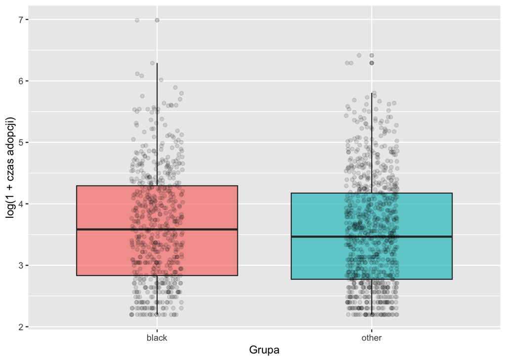

```r
cat_data %>%
  ggplot(aes(x = black_group, y = log_time, fill = black_group)) +
  geom_boxplot(alpha = 0.65, outlier.alpha = 0.25) +
  geom_jitter(width = 0.12, alpha = 0.12) +
  labs(
    x = "Grupa",
    y = "log(1 + czas adopcji)",
    fill = "Grupa"
  ) +
  theme(legend.position = "none")
```

Dodatnia wartość statystyki oznacza dłuższy typowy czas adopcji w grupie czarnych kotów.

### Bootstrapowy przedział ufności

```r
set.seed(2026)

bootstrap_dist <- cat_data %>%
  specify(log_time ~ black_group) %>%
  generate(reps = 2000, type = "bootstrap") %>%
  calculate(stat = "diff in medians", order = c("black", "other"))

bootstrap_ci <- bootstrap_dist %>%
  get_ci(level = 0.95, type = "percentile")

bootstrap_ci
```

```
# A tibble: 1 × 2
  lower_ci upper_ci
     <dbl>    <dbl>
1  -0.0588    0.272
```

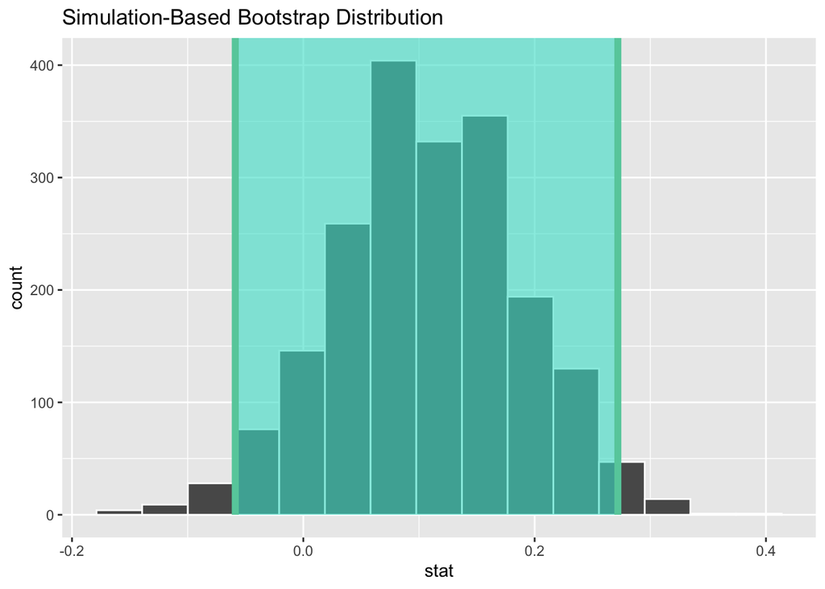

```r
visualize(bootstrap_dist) +
  shade_confidence_interval(bootstrap_ci)
```

Jeżeli przedział ufności obejmuje zero, dane nie dają mocnej podstawy do wniosku o różnicy median. Jeżeli cały przedział leży po jednej stronie zera, wniosek wskazuje odpowiednio dłuższy lub krótszy czas adopcji czarnych kotów.

### Test permutacyjny

```r
set.seed(2026)

permutation_null <- cat_data %>%
  specify(log_time ~ black_group) %>%
  hypothesize(null = "independence") %>%
  generate(reps = 2000, type = "permute") %>%
  calculate(stat = "diff in medians", order = c("black", "other"))

perm_p_value <- permutation_null %>%
  get_p_value(obs_stat = observed_diff, direction = "two-sided")

perm_p_value
```

```
# A tibble: 1 × 1
  p_value
    <dbl>
1   0.184
```

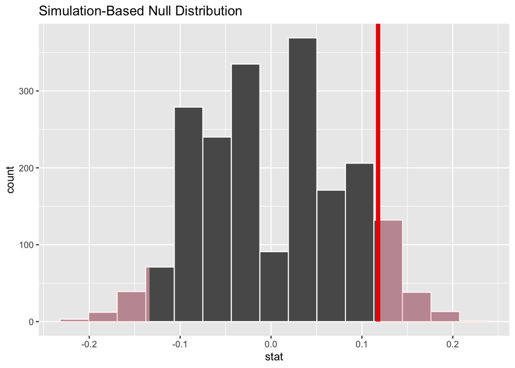

```r
visualize(permutation_null) +
  shade_p_value(obs_stat = observed_diff, direction = "two-sided")
```

Wartość `p-value` mówi, jak często przy braku związku między umaszczeniem a czasem adopcji otrzymalibyśmy różnicę median co najmniej tak ekstremalną jak obserwowana.

### Porównanie wniosków i ograniczenia

```r
tibble(
  metoda = c("bootstrap CI", "permutation test"),
  wynik = c(
    paste0(
      "[",
      round(bootstrap_ci$lower_ci, 3),
      ", ",
      round(bootstrap_ci$upper_ci, 3),
      "]"
    ),
    paste0("p-value = ", round(perm_p_value$p_value, 4))
  )
)
```

```
# A tibble: 2 × 2
  metoda           wynik
  <chr>            <chr>
1 bootstrap CI     [-0.059, 0.272]
2 permutation test p-value = 0.184
```

Obie procedury odpowiadają na spójne, ale nieidentyczne pytania. Bootstrapowy przedział ufności opisuje niepewność estymacji różnicy median, a test permutacyjny ocenia zgodność danych z hipotezą niezależności. Ograniczeniem analizy jest pominięcie obserwacji cenzorowanych (`event == 0`); pełniejsza analiza czasu do adopcji wymagałaby metod analizy przeżycia.

## Zadanie 2. Rozbudowany preprocessing, porównanie workflowów i testy jakości

### Podział danych i schemat resamplingu

Używamy odłożonego zbioru testowego do końcowej oceny oraz walidacji krzyżowej na zbiorze treningowym do porównania workflowów. Dla skrócenia czasu obliczeń pracujemy na losowej próbie danych, zachowując powtarzalność. Zmienną wynikową `avg_price_per_room` przekształcamy przez `log()`, ponieważ ceny pokoi są dodatnie i mają zwykle rozkład prawostronnie skośny. Transformacja ogranicza wpływ bardzo drogich rezerwacji i sprawia, że błąd modelu jest bliższy błędowi względnemu niż bezwzględnej różnicy cen. Wszystkie porównania modeli w tym zadaniu dotyczą więc predykcji `log(avg_price_per_room)`.

```r
set.seed(2026)

hotel_data <- hotel_rates %>%
  slice_sample(n = 900) %>%
  mutate(avg_price_per_room = log(avg_price_per_room))

hotel_split <- initial_split(
  hotel_data,
  prop = 0.8,
  strata = avg_price_per_room
)

hotel_train <- training(hotel_split)
hotel_test <- testing(hotel_split)

set.seed(2026)
hotel_folds <- vfold_cv(
  hotel_train,
  v = 10,
  strata = avg_price_per_room
)
```

Stratyfikacja względem ceny ogranicza ryzyko, że w którymś foldzie zabraknie obserwacji z niskich lub wysokich segmentów cenowych. Wyniki z resamplingu są używane do wyboru workflowu; dane testowe pozostają odłożone do końca.

### Trzy reguły preprocessingu

Pierwsza reguła jest konserwatywna: usuwa datę jako obiekt kalendarzowy, uzupełnia braki, grupuje rzadkie poziomy i koduje zmienne nominalne.

```r
hotel_rec_base <- recipe(avg_price_per_room ~ ., data = hotel_train) %>%
  step_rm(arrival_date) %>%
  step_impute_median(all_numeric_predictors()) %>%
  step_impute_mode(all_nominal_predictors()) %>%
  step_other(all_nominal_predictors(), threshold = 0.03, other = "rzadkie") %>%
  step_dummy(all_nominal_predictors()) %>%
  step_zv(all_predictors()) %>%
  step_normalize(all_numeric_predictors())
```

Druga reguła dodaje inżynierię cech opisujących długość pobytu, liczbę gości, wcześniejszą aktywność klienta i oczekiwanie.

```r
hotel_rec_engineered <- recipe(avg_price_per_room ~ ., data = hotel_train) %>%
  step_rm(arrival_date) %>%
  step_mutate(
    total_nights = stays_in_weekend_nights + stays_in_week_nights,
    total_guests = adults + children + babies,
    has_previous_activity =
      as.numeric(previous_cancellations + previous_bookings_not_canceled > 0),
    long_wait = as.numeric(days_in_waiting_list > 0)
  ) %>%
  step_rm(lead_time) %>%
  step_impute_median(all_numeric_predictors()) %>%
  step_impute_mode(all_nominal_predictors()) %>%
  step_other(all_nominal_predictors(), threshold = 0.02, other = "rzadkie") %>%
  step_dummy(all_nominal_predictors()) %>%
  step_zv(all_predictors()) %>%
  step_normalize(all_numeric_predictors())
```

Trzecia reguła jest ukierunkowana na redukcję wymiaru po kodowaniu zmiennych nominalnych.

```r
hotel_rec_pca <- recipe(avg_price_per_room ~ ., data = hotel_train) %>%
  step_rm(arrival_date) %>%
  step_impute_median(all_numeric_predictors()) %>%
  step_impute_mode(all_nominal_predictors()) %>%
  step_other(all_nominal_predictors(), threshold = 0.02, other = "rzadkie") %>%
  step_dummy(all_nominal_predictors()) %>%
  step_zv(all_predictors()) %>%
  step_normalize(all_numeric_predictors()) %>%
  step_pca(all_numeric_predictors(), num_comp = 12)
```

Każda reguła obejmuje braki danych, predyktory nominalne, predyktory liczbowe, rzadkie lub problematyczne poziomy oraz dodatkowy pomysł przetwarzania.

### Dziewięć workflowów

Modele odpowiadają wymaganym rodzinom: ensemble drzewiasty, model splajnowy MARS oraz SVM z jądrem radialnym.

```r
forest_spec <- rand_forest(trees = 80, min_n = 10) %>%
  set_engine("ranger") %>%
  set_mode("regression")

mars_spec <- mars(num_terms = 20, prod_degree = 2) %>%
  set_engine("earth") %>%
  set_mode("regression")

svm_spec <- svm_rbf(cost = 0.5, rbf_sigma = 0.01) %>%
  set_engine("kernlab") %>%
  set_mode("regression")

hotel_workflows <- workflow_set(
  preproc = list(
    base = hotel_rec_base,
    engineered = hotel_rec_engineered,
    pca = hotel_rec_pca
  ),
  models = list(
    forest = forest_spec,
    mars = mars_spec,
    svm = svm_spec
  ),
  cross = TRUE
)

hotel_workflows
```

```
# A workflow set/tibble: 9 × 4
  wflow_id          info             option    result
  <chr>             <list>           <list>    <list>
1 base_forest       <tibble [1 × 4]> <opts[0]> <list [0]>
2 base_mars         <tibble [1 × 4]> <opts[0]> <list [0]>
3 base_svm          <tibble [1 × 4]> <opts[0]> <list [0]>
4 engineered_forest <tibble [1 × 4]> <opts[0]> <list [0]>
5 engineered_mars   <tibble [1 × 4]> <opts[0]> <list [0]>
6 engineered_svm    <tibble [1 × 4]> <opts[0]> <list [0]>
7 pca_forest        <tibble [1 × 4]> <opts[0]> <list [0]>
8 pca_mars          <tibble [1 × 4]> <opts[0]> <list [0]>
9 pca_svm           <tibble [1 × 4]> <opts[0]> <list [0]>
```

### Ocena workflowów w tym samym resamplingu

```r
set.seed(2026)

hotel_res <- workflow_map(
  hotel_workflows,
  "fit_resamples",
  resamples = hotel_folds,
  metrics = metric_set(rmse, mae, rsq),
  control = control_resamples(save_pred = TRUE),
  verbose = FALSE
)
```

```r
hotel_metrics <- collect_metrics(hotel_res)

hotel_metrics %>%
  filter(.metric == "rmse") %>%
  arrange(mean) %>%
  select(wflow_id, mean, std_err, n)
```

```
# A tibble: 9 × 4
  wflow_id           mean std_err     n
  <chr>             <dbl>   <dbl> <int>
1 base_mars         0.207 0.00352    10
2 engineered_mars   0.226 0.00811    10
3 base_svm          0.237 0.00803    10
4 base_forest       0.239 0.00852    10
5 engineered_forest 0.254 0.00900    10
6 engineered_svm    0.259 0.0101     10
7 pca_forest        0.413 0.00926    10
8 pca_mars          0.424 0.0131     10
9 pca_svm           0.433 0.0116     10
```

### Ranking i stabilność wyników

```r
hotel_ranking <- hotel_metrics %>%
  filter(.metric == "rmse") %>%
  arrange(mean)

hotel_ranking
```

```
# A tibble: 9 × 9
  wflow_id          .config preproc model .metric .estimator  mean     n std_err
  <chr>             <chr>   <chr>   <chr> <chr>   <chr>      <dbl> <int>   <dbl>
1 base_mars         pre0_m… recipe  mars  rmse    standard   0.207    10 0.00352
2 engineered_mars   pre0_m… recipe  mars  rmse    standard   0.226    10 0.00811
3 base_svm          pre0_m… recipe  svm_… rmse    standard   0.237    10 0.00803
4 base_forest       pre0_m… recipe  rand… rmse    standard   0.239    10 0.00852
5 engineered_forest pre0_m… recipe  rand… rmse    standard   0.254    10 0.00900
6 engineered_svm    pre0_m… recipe  svm_… rmse    standard   0.259    10 0.0101
7 pca_forest        pre0_m… recipe  rand… rmse    standard   0.413    10 0.00926
8 pca_mars          pre0_m… recipe  mars  rmse    standard   0.424    10 0.0131
9 pca_svm           pre0_m… recipe  svm_… rmse    standard   0.433    10 0.0116
```

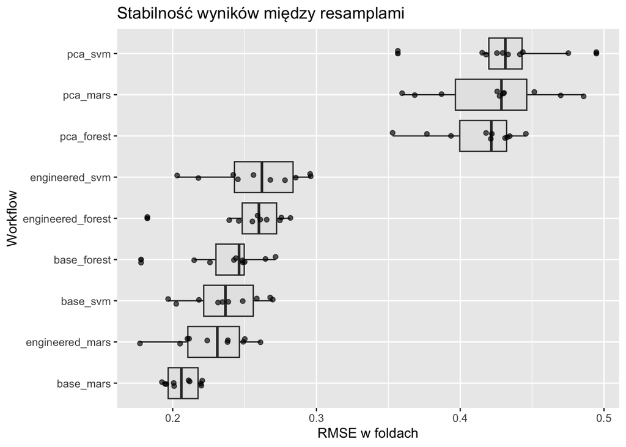

```r
hotel_fold_rmse <- hotel_res %>%
  collect_metrics(summarize = FALSE) %>%
  filter(.metric == "rmse")

hotel_fold_rmse %>%
  ggplot(aes(x = reorder(wflow_id, .estimate, median), y = .estimate)) +
  geom_boxplot(fill = "grey90") +
  geom_point(alpha = 0.65, position = position_jitter(width = 0.08)) +
  coord_flip() +
  labs(
    x = "Workflow",
    y = "RMSE w foldach",
    title = "Stabilność wyników między resamplami"
  )
```

### Formalne testy różnic jakości

Porównujemy najlepszy workflow z trzema kolejnymi konkurentami. Test jest sparowany, ponieważ każdy workflow był oceniany na tych samych foldach.

```r
best_hotel_wflow <- hotel_ranking$wflow_id[1]
hotel_competitors <- hotel_ranking$wflow_id[2:4]

hotel_tests <- purrr::map_dfr(hotel_competitors, function(comp_id) {
  wide <- hotel_fold_rmse %>%
    filter(wflow_id %in% c(best_hotel_wflow, comp_id)) %>%
    select(id, wflow_id, .estimate) %>%
    pivot_wider(names_from = wflow_id, values_from = .estimate)

  test <- t.test(
    wide[[comp_id]],
    wide[[best_hotel_wflow]],
    paired = TRUE,
    alternative = "greater"
  )

  tibble(
    best = best_hotel_wflow,
    competitor = comp_id,
    mean_rmse_difference = mean(wide[[comp_id]] - wide[[best_hotel_wflow]]),
    p_value = test$p.value
  )
})

hotel_tests
```

```
# A tibble: 3 × 4
  best      competitor      mean_rmse_difference p_value
  <chr>     <chr>                          <dbl>   <dbl>
1 base_mars engineered_mars               0.0198 0.0181
2 base_mars base_svm                      0.0300 0.00166
3 base_mars base_forest                   0.0321 0.00185
```

Dodatnia różnica oznacza przewagę najlepszego workflowu, bo konkurent ma większy `rmse`. Małe wartości `p-value` wskazują, że przewaga jest stabilna w foldach, a nie wynika tylko z pojedynczego podziału.

### Model końcowy i ocena na danych odłożonych

```r
final_hotel_wf <- hotel_workflows %>%
  extract_workflow(best_hotel_wflow)

final_hotel_fit <- fit(final_hotel_wf, data = hotel_train)

hotel_test_pred <- hotel_test %>%
  select(avg_price_per_room) %>%
  bind_cols(predict(final_hotel_fit, new_data = hotel_test))

hotel_test_metrics <- metric_set(rmse, mae, rsq)(
  hotel_test_pred,
  truth = avg_price_per_room,
  estimate = .pred
)

hotel_test_metrics
```

```
# A tibble: 3 × 3
  .metric .estimator .estimate
  <chr>   <chr>          <dbl>
1 rmse    standard       0.240
2 mae     standard       0.177
3 rsq     standard       0.838
```

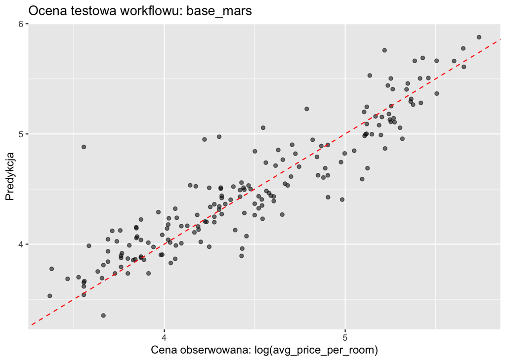

```r
hotel_test_pred %>%
  ggplot(aes(x = avg_price_per_room, y = .pred)) +
  geom_point(alpha = 0.55) +
  geom_abline(lty = 2, color = "red") +
  labs(
    x = "Cena obserwowana: log(avg_price_per_room)",
    y = "Predykcja",
    title = paste("Ocena testowa workflowu:", best_hotel_wflow)
  )
```

Jeżeli metryka testowa jest zbliżona do średniej z resamplingu, ocena walidacyjna była spójna z oceną na danych odłożonych. Duża rozbieżność wskazywałaby na niestabilność wyboru lub niedoszacowanie błędu generalizacji.

## Zadanie 3. Tuning, metoda wyścigów i wybór konfiguracji na podstawie testów

```r
library(rules)
library(finetune)
library(themis)
```

### Przygotowanie danych

Dane mają wiele predyktorów numerycznych oraz nierównoliczne klasy. Dlatego preprocessing musi jednocześnie ograniczać problemy jakości predyktorów i kontrolować wpływ dominujących klas na dopasowanie modelu.

```r
set.seed(2026)

hepatic_data <- hepatic_injury_qsar %>%
  mutate(class = factor(class))

hepatic_data %>%
  count(class) %>%
  mutate(prop = n / sum(n))
```

```
# A tibble: 3 × 3
  class      n  prop
  <ord>  <int> <dbl>
1 none     106 0.377
2 mild     145 0.516
3 severe    30 0.107
```

Klasa `severe` jest wyraźnie mniej liczna niż pozostałe klasy, więc model optymalizowany bez korekty może uzyskiwać akceptowalną trafność głównie przez lepsze rozpoznawanie klas częstszych. Z tego powodu w recepturze stosujemy nadpróbkowanie klasy mniejszościowej. Nie traktujemy go jako sposobu “tworzenia informacji”, lecz jako mechanizm zmiany wag obserwacji widzianych przez algorytm w trakcie uczenia.

```r
hepatic_split <- initial_split(hepatic_data, prop = 0.8, strata = class)
hepatic_train <- training(hepatic_split)
hepatic_test <- testing(hepatic_split)

set.seed(2026)
hepatic_folds <- vfold_cv(hepatic_train, v = 10, strata = class)
```

```r
hepatic_rec <- recipe(class ~ ., data = hepatic_train) %>%
  step_zv(all_predictors()) %>%
  step_corr(all_numeric_predictors(), threshold = 0.90) %>%
  step_upsample(class, over_ratio = 0.7, skip = TRUE)
```

Uzasadnienie kroków:

- `step_zv()` usuwa predyktory o zerowej wariancji, które nie rozróżniają klas i mogą powodować problemy numeryczne lub zbędnie zwiększać wymiar danych.
- `step_corr()` ogranicza grupy silnie współliniowych predyktorów. W danych QSAR wiele zmiennych opisuje podobne sygnały biologiczne, więc redukcja korelacji zmniejsza redundancję i ryzyko niestabilnego dopasowania.
- `step_upsample()` zwiększa reprezentację klas mniejszościowych w częściach treningowych resamplingu. Dzięki temu model jest mniej zachęcany do ignorowania klasy `severe`.
- `skip = TRUE` zabezpiecza przed sztucznym zmienianiem rozkładu klas w danych walidacyjnych i testowych. Ocena ma być wykonana na naturalnym rozkładzie klas, a nie na danych zmodyfikowanych przez nadpróbkowanie.

### Schemat resamplingu i metryki

Używamy tych samych foldów dla obu rodzin modeli, aby późniejsze porównanie było sparowane. W wieloklasowym i niezbalansowanym problemie zwykła `accuracy` nie jest dobrą metryką wyboru, ponieważ model może uzyskać pozornie dobry wynik przez poprawne klasyfikowanie głównie klas liczniejszych. Metryką wyboru jest więc `bal_accuracy`, czyli średnia czułość liczona po klasach. Każda klasa ma w niej podobną wagę, również klasa `severe`. Jako metryki uzupełniające wykorzystujemy `kap`, która koryguje trafność o zgodność losową, oraz `mn_log_loss`, która ocenia jakość prawdopodobieństw predykcyjnych.

```r
hepatic_metrics <- metric_set(bal_accuracy, kap, mn_log_loss)
```

### Regularna siatka hiperparametrów

Pierwszą rodziną modeli jest boosting drzew. Stroimy liczbę drzew, głębokość drzew, tempo uczenia i minimalną liczebność liścia.

```r
xgb_spec <- boost_tree(
  trees = tune(),
  tree_depth = tune(),
  learn_rate = tune(),
  min_n = tune(),
  loss_reduction = 0,
  sample_size = 0.8
) %>%
  set_engine("xgboost", nthread = 1) %>%
  set_mode("classification")

xgb_wf <- workflow() %>%
  add_recipe(hepatic_rec) %>%
  add_model(xgb_spec)
```

```r
xgb_grid <- grid_regular(
  trees(c(50L, 100L)),
  tree_depth(c(2L, 5L)),
  learn_rate(c(-2, -1)),
  min_n(c(5L, 15L)),
  levels = c(2, 2, 2, 2)
)

xgb_grid
```

```
# A tibble: 16 × 4
   trees tree_depth learn_rate min_n
   <int>      <int>      <dbl> <int>
 1    50          2       0.01     5
 2   100          2       0.01     5
 3    50          5       0.01     5
 4   100          5       0.01     5
 5    50          2       0.1      5
 6   100          2       0.1      5
 7    50          5       0.1      5
 8   100          5       0.1      5
 9    50          2       0.01    15
10   100          2       0.01    15
11    50          5       0.01    15
12   100          5       0.01    15
13    50          2       0.1     15
14   100          2       0.1     15
15    50          5       0.1     15
16   100          5       0.1     15
```

```r
set.seed(2026)

xgb_res <- tune_grid(
  xgb_wf,
  resamples = hepatic_folds,
  grid = xgb_grid,
  metrics = hepatic_metrics,
  control = control_grid(save_pred = TRUE)
)
```

```r
show_best(xgb_res, metric = "bal_accuracy", n = 8)
```

```
# A tibble: 8 × 10
  trees min_n tree_depth learn_rate .metric      .estimator  mean     n std_err
  <int> <int>      <int>      <dbl> <chr>        <chr>      <dbl> <int>   <dbl>
1   100    15          5       0.1  bal_accuracy macro      0.578    10  0.0246
2   100    15          2       0.1  bal_accuracy macro      0.574    10  0.0311
3    50    15          2       0.1  bal_accuracy macro      0.572    10  0.0336
4    50    15          5       0.1  bal_accuracy macro      0.570    10  0.0268
5    50     5          5       0.1  bal_accuracy macro      0.566    10  0.0219
6   100    15          5       0.01 bal_accuracy macro      0.559    10  0.0215
7   100     5          5       0.01 bal_accuracy macro      0.556    10  0.0203
8   100     5          5       0.1  bal_accuracy macro      0.555    10  0.0244
# ℹ 1 more variable: .config <chr>
```

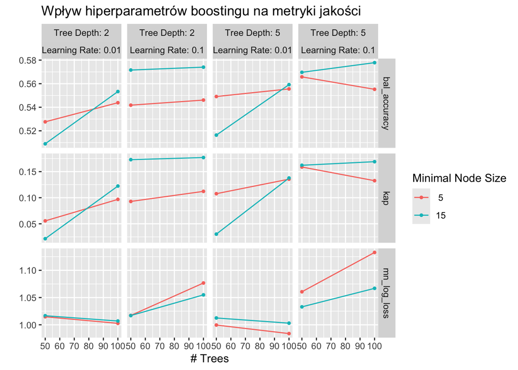

```r
autoplot(xgb_res) +
  labs(title = "Wpływ hiperparametrów boostingu na metryki jakości")
```

### Metoda wyścigów

Drugą rodziną modeli są reguły C5.0. Procedura wyścigowa eliminuje słabe konfiguracje po części resampli.

```r
c5_spec <- C5_rules(
  trees = tune(),
  min_n = tune()
) %>%
  set_engine("C5.0") %>%
  set_mode("classification")

c5_wf <- workflow() %>%
  add_recipe(hepatic_rec) %>%
  add_model(c5_spec)
```

```r
c5_grid <- grid_regular(
  trees(c(1L, 20L)),
  min_n(c(2L, 20L)),
  levels = c(4, 3)
)

c5_grid
```

```
# A tibble: 12 × 2
   trees min_n
   <int> <int>
 1     1     2
 2     7     2
 3    13     2
 4    20     2
 5     1    11
 6     7    11
 7    13    11
 8    20    11
 9     1    20
10     7    20
11    13    20
12    20    20
```

```r
set.seed(2026)

c5_race <- tune_race_anova(
  c5_wf,
  resamples = hepatic_folds,
  grid = c5_grid,
  metrics = hepatic_metrics,
  control = control_race(verbose_elim = TRUE)
)
```

```r
show_best(c5_race, metric = "bal_accuracy", n = 8)
```

```
# A tibble: 4 × 8
  trees min_n .metric      .estimator  mean     n std_err .config
  <int> <int> <chr>        <chr>      <dbl> <int>   <dbl> <chr>
1    20     2 bal_accuracy macro      0.625    10  0.0188 pre0_mod10_post0
2    13     2 bal_accuracy macro      0.599    10  0.0136 pre0_mod07_post0
3     7     2 bal_accuracy macro      0.596    10  0.0157 pre0_mod04_post0
4     1     2 bal_accuracy macro      0.575    10  0.0251 pre0_mod01_post0
```

Liczba ocen dla konfiguracji pokazuje, które kandydatury odpadły wcześniej.

```r
c5_race %>%
  collect_metrics(summarize = FALSE) %>%
  count(.config, .metric) %>%
  arrange(.metric, n)
```

```
# A tibble: 12 × 3
   .config          .metric          n
   <chr>            <chr>        <int>
 1 pre0_mod01_post0 bal_accuracy    10
 2 pre0_mod04_post0 bal_accuracy    10
 3 pre0_mod07_post0 bal_accuracy    10
 4 pre0_mod10_post0 bal_accuracy    10
 5 pre0_mod01_post0 kap             10
 6 pre0_mod04_post0 kap             10
 7 pre0_mod07_post0 kap             10
 8 pre0_mod10_post0 kap             10
 9 pre0_mod01_post0 mn_log_loss     10
10 pre0_mod04_post0 mn_log_loss     10
11 pre0_mod07_post0 mn_log_loss     10
12 pre0_mod10_post0 mn_log_loss     10
```

### Porównanie najlepszych konfiguracji testem sparowanym

Wybieramy najlepsze konfiguracje według `bal_accuracy`, a następnie porównujemy ich wyniki fold po foldzie. To porównanie jest bardziej adekwatne niż test zwykłej trafności, bo ocenia, czy modele podobnie radzą sobie ze wszystkimi klasami, a nie tylko z klasami dominującymi.

```r
best_xgb <- select_best(xgb_res, metric = "bal_accuracy")
best_c5 <- select_best(c5_race, metric = "bal_accuracy")

best_xgb
```

```
# A tibble: 1 × 5
  trees min_n tree_depth learn_rate .config
  <int> <int>      <int>      <dbl> <chr>
1   100    15          5        0.1 pre0_mod16_post0
```

```r
best_c5
```

```
# A tibble: 1 × 3
  trees min_n .config
  <int> <int> <chr>
1    20     2 pre0_mod10_post0
```

```r
xgb_best_fold <- xgb_res %>%
  collect_metrics(summarize = FALSE) %>%
  filter(.metric == "bal_accuracy", .config == best_xgb$.config) %>%
  transmute(id, model = "xgboost", bal_accuracy = .estimate)

c5_best_fold <- c5_race %>%
  collect_metrics(summarize = FALSE) %>%
  filter(.metric == "bal_accuracy", .config == best_c5$.config) %>%
  transmute(id, model = "c5_rules", bal_accuracy = .estimate)

best_fold_wide <- bind_rows(xgb_best_fold, c5_best_fold) %>%
  pivot_wider(names_from = model, values_from = bal_accuracy)

best_fold_wide
```

```
# A tibble: 10 × 3
   id     xgboost c5_rules
   <chr>    <dbl>    <dbl>
 1 Fold01   0.604    0.626
 2 Fold02   0.720    0.644
 3 Fold03   0.557    0.717
 4 Fold04   0.598    0.619
 5 Fold05   0.432    0.684
 6 Fold06   0.582    0.594
 7 Fold07   0.640    0.499
 8 Fold08   0.528    0.661
 9 Fold09   0.606    0.610
10 Fold10   0.511    0.593
```

```r
balanced_accuracy_test <- t.test(
  best_fold_wide$xgboost,
  best_fold_wide$c5_rules,
  paired = TRUE
)

balanced_accuracy_test
```

```
    Paired t-test

data:  best_fold_wide$xgboost and best_fold_wide$c5_rules
t = -1.2946, df = 9, p-value = 0.2277
alternative hypothesis: true mean difference is not equal to 0
95 percent confidence interval:
 -0.12879667  0.03503479
sample estimates:
mean difference
    -0.04688094
```

```r
mean_bal_accuracy_diff <- mean(best_fold_wide$xgboost - best_fold_wide$c5_rules)

chosen_model <- if (
  balanced_accuracy_test$p.value < 0.05 && mean_bal_accuracy_diff > 0
) {
  "xgboost"
} else if (
  balanced_accuracy_test$p.value < 0.05 && mean_bal_accuracy_diff < 0
) {
  "c5_rules"
} else if (mean_bal_accuracy_diff >= 0) {
  "xgboost"
} else {
  "c5_rules"
}

chosen_model
```

```
[1] "c5_rules"
```

Jeżeli test nie wskazuje istotnej różnicy, konfiguracje można uznać za praktycznie nierozróżnialne statystycznie w tym schemacie resamplingu. W takim przypadku wybór można oprzeć na średniej jakości, prostocie lub koszcie obliczeniowym.

### Finalizacja, ocena testowa i macierz pomyłek

```r
if (chosen_model == "xgboost") {
  final_hepatic_wf <- finalize_workflow(xgb_wf, best_xgb)
} else {
  final_hepatic_wf <- finalize_workflow(c5_wf, best_c5)
}

final_hepatic_fit <- fit(final_hepatic_wf, data = hepatic_train)

hepatic_test_pred <- hepatic_test %>%
  select(class) %>%
  bind_cols(predict(final_hepatic_fit, new_data = hepatic_test)) %>%
  bind_cols(predict(final_hepatic_fit, new_data = hepatic_test, type = "prob"))
```

```r
prob_cols <- paste0(".pred_", levels(hepatic_test_pred$class))

hepatic_metrics(
  hepatic_test_pred,
  truth = class,
  estimate = .pred_class,
  !!!rlang::syms(prob_cols)
)
```

```
# A tibble: 3 × 3
  .metric      .estimator .estimate
  <chr>        <chr>          <dbl>
1 bal_accuracy macro         0.483
2 kap          multiclass   -0.0894
3 mn_log_loss  multiclass    2.31
```

```r
hepatic_conf_mat <- conf_mat(hepatic_test_pred, truth = class, estimate = .pred_class)
hepatic_conf_mat
```

```
          Truth
Prediction none mild severe
    none      5   14      0
    mild     12   13      4
    severe    5    2      2
```

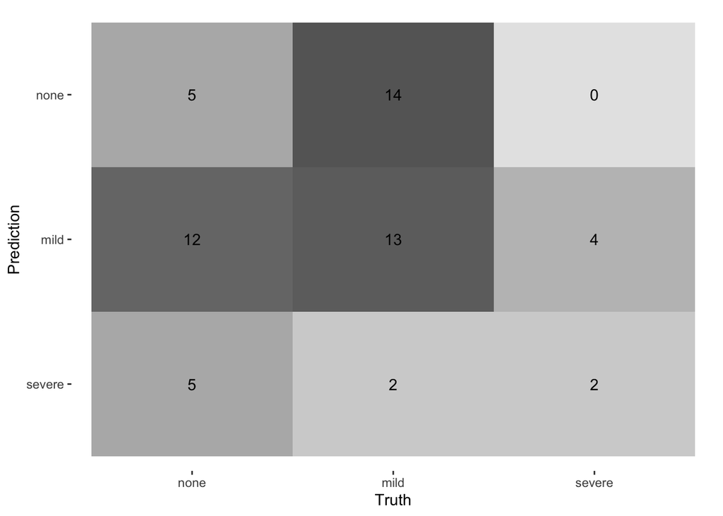

```r
autoplot(hepatic_conf_mat, type = "heatmap")
```

Najważniejsze błędy interpretujemy przez klasy, w których model najczęściej myli poziomy uszkodzenia. Przy niezbalansowanych danych szczególną uwagę należy zwrócić na klasę najmniej liczną, ponieważ wysoka ogólna trafność może ukrywać słabą rozpoznawalność tej klasy.

### Korzyść praktyczna metody wyścigów

```r
tibble(
  procedura = c("regular grid: xgboost", "racing: C5.0 rules"),
  liczba_kandydatow = c(nrow(xgb_grid), nrow(c5_grid)),
  najlepsza_bal_accuracy = c(
    show_best(xgb_res, metric = "bal_accuracy", n = 1)$mean,
    show_best(c5_race, metric = "bal_accuracy", n = 1)$mean
  )
)
```

```
# A tibble: 2 × 3
  procedura             liczba_kandydatow najlepsza_bal_accuracy
  <chr>                             <int>                  <dbl>
1 regular grid: xgboost                16                  0.578
2 racing: C5.0 rules                   12                  0.625
```

Metoda wyścigów daje korzyść praktyczną, gdy eliminuje część słabych kandydatów bez pogorszenia jakości najlepszego modelu. W tym zadaniu należy ocenić tę korzyść razem z wynikiem testu sparowanego i liczbą konfiguracji, które nie musiały być oceniane do końca. Należy jednak pamiętać, że to porównanie odbywało się na różnych modelach więc nie do końca można traktować je jako wiarygodne.